# T-Bank product case

2025-08-22

## Предобработка данных

Датасет содержит переменные в неочищенном виде: названия одних и тех же регионов написаны по-разному (так как, вероятно, вводились пользователями вручную), значения даты и времени не унифицированы, переменная, храняющая километраж поездок содержит аномальные выбросы. На данном этапе я очищаю данные и готовлю их к работе с помощью **изменения типов переменных, удаления выбросов, унификации значений.**

```r
# загружаю датасет и привожу переменные к нужному виду
kicksharing <- read.csv(file = 'kicksharing.csv',
                   header = TRUE,
                   sep = ',',
                   na.strings = c("", "NA"),
                   colClasses = c('character', 'character', 'factor', 'numeric', 'factor', 'factor', 'factor', 'numeric', 'numeric', 'numeric', 'factor', 'numeric', 'character', 'character', 'character', 'factor', 'character', 'numeric', 'numeric', 'numeric'))

# отдельно работаю с типом данных "дата и время"

kicksharing$created_dttm <- as.POSIXct(kicksharing$created_dttm, format = "%Y-%m-%d %H:%M:%OS")
kicksharing$created_dttm <- as.POSIXct(kicksharing$created_dttm, format = "%Y-%m-%d %H:%M:%OS")
kicksharing$book_start_dttm <- as.POSIXct(kicksharing$book_start_dttm, format = "%Y-%m-%d %H:%M:%OS")
kicksharing$book_end_dttm <- as.POSIXct(kicksharing$book_end_dttm, format = "%Y-%m-%d %H:%M:%OS")
kicksharing$local_book_start_dttm <- as.POSIXct(kicksharing$local_book_start_dttm, format = "%Y-%m-%d %H:%M:%OS")

# перезаписываю датасет без клиентов с аномальным километражом

iqr <- IQR(kicksharing$distance_km)

lower_bound = quantile(kicksharing$distance_km, 0.25) - 1.5 * iqr
upper_bound = quantile(kicksharing$distance_km, 0.75) + 1.5 * iqr

kicksharing_clean <- kicksharing %>% filter(distance_km <= upper_bound)

# привожу регионы к правильному виду
kicksharing_clean$lvn_state_nm <- gsub("^.*\\МОСКВА\\b.*$", "МОСКВА", kicksharing_clean$lvn_state_nm)
kicksharing_clean$lvn_state_nm <- gsub("^.*\\САНКТ-ПЕТЕРБУРГ\\b.*$", "САНКТ-ПЕТЕРБУРГ", kicksharing_clean$lvn_state_nm)
kicksharing_clean$lvn_state_nm <- gsub("^.*\\ТАТАРСТАН\\b.*$", "РЕСП ТАТАРСТАН", kicksharing_clean$lvn_state_nm)
kicksharing_clean$lvn_state_nm <- gsub("^.*\\МОСКОВСКАЯ\\b.*$", "МОСКОВСКАЯ ОБЛ", kicksharing_clean$lvn_state_nm)
kicksharing_clean$lvn_state_nm <- gsub("^.*\\АСТРАХАНСКАЯ\\b.*$", "АСТРАХАНСКАЯ ОБЛ", kicksharing_clean$lvn_state_nm)
kicksharing_clean$lvn_state_nm <- gsub("^.*\\ВОЛГОГРАДСКАЯ\\b.*$", "ВОЛГОГРАДСКАЯ ОБЛ", kicksharing_clean$lvn_state_nm)
kicksharing_clean$lvn_state_nm <- gsub("^.*\\ГОМЕЛЬСКАЯ\\b.*$", "ГОМЕЛЬСКАЯ ОБЛ", kicksharing_clean$lvn_state_nm)
kicksharing_clean$lvn_state_nm <- gsub("^.*\\ИРКУТСКАЯ\\b.*$", "ИРКУТСКАЯ ОБЛ", kicksharing_clean$lvn_state_nm)
kicksharing_clean$lvn_state_nm <- gsub("^.*\\КЕМЕРОВСКАЯ\\b.*$", "КЕМЕРОВСКАЯ ОБЛ", kicksharing_clean$lvn_state_nm)
kicksharing_clean$lvn_state_nm <- gsub("^.*\\ЛЕНИНГРАДСКАЯ\\b.*$", "ЛЕНИНГРАДСКАЯ ОБЛ", kicksharing_clean$lvn_state_nm)
kicksharing_clean$lvn_state_nm <- gsub("^.*\\ЧЕЛЯБИНСКАЯ\\b.*$", "ЧЕЛЯБИНСКАЯ ОБЛ", kicksharing_clean$lvn_state_nm)
kicksharing_clean$lvn_state_nm <- gsub("^.*\\АЛТАЙСКИЙ\\b.*$", "АЛТАЙСКИЙ КРАЙ", kicksharing_clean$lvn_state_nm)
kicksharing_clean$lvn_state_nm <- gsub("^.*\\КРАСНОДАРСКИЙ\\b.*$", "КРАСНОДАРСКИЙ КРАЙ", kicksharing_clean$lvn_state_nm)
kicksharing_clean$lvn_state_nm <- gsub("^.*\\КРАСНОЯРСКИЙ\\b.*$", "КРАСНОЯРСКИЙ КРАЙ", kicksharing_clean$lvn_state_nm)
kicksharing_clean$lvn_state_nm <- gsub("^.*\\ПЕРМСКИЙ\\b.*$", "ПЕРМСКИЙ КРАЙ", kicksharing_clean$lvn_state_nm)
kicksharing_clean$lvn_state_nm <- gsub("^.*\\ХАБАРОВСКИЙ\\b.*$", "ХАБАРОВСКИЙ КРАЙ", kicksharing_clean$lvn_state_nm)
kicksharing_clean$lvn_state_nm <- gsub("^.*\\ПРИМОРСКИЙ\\b.*$", "ПРИМОРСКИЙ КРАЙ", kicksharing_clean$lvn_state_nm)
kicksharing_clean$lvn_state_nm <- gsub("^.*\\КАМЧАТСКИЙ\\b.*$", "КАМЧАТСКИЙ КРАЙ", kicksharing_clean$lvn_state_nm)
kicksharing_clean$lvn_state_nm <- gsub("^.*\\СТАВРОПОЛЬСКИЙ\\b.*$", "СТАВРОПОЛЬСКИЙ КРАЙ", kicksharing_clean$lvn_state_nm)
kicksharing_clean$lvn_state_nm <- gsub("^.*\\ХАНТЫ-МАНСИЙСКИЙ\\b.*$", "ХАНТЫ-МАНСИЙСКИЙ АО", kicksharing_clean$lvn_state_nm)
kicksharing_clean$lvn_state_nm <- gsub("^.*\\ЧУВАШИЯ\\b.*$", "РЕСП ЧУВАШИЯ", kicksharing_clean$lvn_state_nm)
kicksharing_clean$lvn_state_nm <- gsub("^.*\\ЯКУТИЯ\\b.*$", "РЕСП САХА/ЯКУТИЯ", kicksharing_clean$lvn_state_nm)
kicksharing_clean$lvn_state_nm <- gsub("^.*\\НОВОСИБИРСКАЯ\\b.*$", "НОВОСИБИРСКАЯ ОБЛ", kicksharing_clean$lvn_state_nm)
kicksharing_clean$lvn_state_nm <- gsub("^.*\\ЯРОСЛАВСКАЯ\\b.*$", "ЯРОСЛАВСКАЯ ОБЛ", kicksharing_clean$lvn_state_nm)
kicksharing_clean$lvn_state_nm <- gsub("^.*\\МУРМАНСКАЯ\\b.*$", "МУРМАНСКАЯ ОБЛ", kicksharing_clean$lvn_state_nm)
kicksharing_clean$lvn_state_nm <- gsub("^.*\\ЕВРЕЙСКАЯ\\b.*$", "ЕВРЕЙСКАЯ АОБЛ", kicksharing_clean$lvn_state_nm)
kicksharing_clean$lvn_state_nm <- gsub("^.*\\КУРГАНСКАЯ\\b.*$", "КУРГАНСКАЯ ОБЛ", kicksharing_clean$lvn_state_nm)
kicksharing_clean$lvn_state_nm <- gsub("^.*\\АМУРСКАЯ\\b.*$", "АМУРСКАЯ ОБЛ", kicksharing_clean$lvn_state_nm)
kicksharing_clean$lvn_state_nm <- gsub("^.*\\БЕЛГОРОДСКАЯ\\b.*$", "БЕЛГОРОДСКАЯ ОБЛ", kicksharing_clean$lvn_state_nm)
kicksharing_clean$lvn_state_nm <- gsub("^.*\\ТОМСКАЯ\\b.*$", "ТОМСКАЯ ОБЛ", kicksharing_clean$lvn_state_nm)
kicksharing_clean$lvn_state_nm <- gsub("^.*\\ТВЕРСКАЯ\\b.*$", "ТВЕРСКАЯ ОБЛ", kicksharing_clean$lvn_state_nm)
kicksharing_clean$lvn_state_nm <- gsub("^.*\\ТЮМЕНСКАЯ\\b.*$", "ТЮМЕНСКАЯ ОБЛ", kicksharing_clean$lvn_state_nm)
kicksharing_clean$lvn_state_nm <- gsub("^.*\\ИВАНОВСКАЯ\\b.*$", "ИВАНОВСКАЯ ОБЛ", kicksharing_clean$lvn_state_nm)
kicksharing_clean$lvn_state_nm <- gsub("^.*\\МОСККОВСКАЯ\\b.*$", "МОСКОВСКАЯ ОБЛ", kicksharing_clean$lvn_state_nm)
kicksharing_clean$lvn_state_nm <- gsub("^.*\\НОВГОРОДСКАЯ\\b.*$", "НОВГОРОДСКАЯ ОБЛ", kicksharing_clean$lvn_state_nm)
kicksharing_clean$lvn_state_nm <- gsub("^.*\\КАЛИНИНГРАДСКАЯ\\b.*$", "КАЛИНИНГРАДСКАЯ ОБЛ", kicksharing_clean$lvn_state_nm)
kicksharing_clean$lvn_state_nm <- gsub("^.*\\ЛИПЕЦКАЯ\\b.*$", "ЛИПЕЦКАЯ ОБЛ", kicksharing_clean$lvn_state_nm)
kicksharing_clean$lvn_state_nm <- gsub("^.*\\НИЖЕГОРОДСКАЯ\\b.*$", "НИЖЕГОРОДСКАЯ ОБЛ", kicksharing_clean$lvn_state_nm)
kicksharing_clean$lvn_state_nm <- gsub("^.*\\ЛЕНЕНГРАДСКАЯ\\b.*$", "ЛЕНИГРАДСКАЯ ОБЛ", kicksharing_clean$lvn_state_nm)
kicksharing_clean$lvn_state_nm <- gsub("^.*\\САМАРСКАЯ\\b.*$", "САМАРСКАЯ ОБЛ", kicksharing_clean$lvn_state_nm)
kicksharing_clean$lvn_state_nm <- gsub("^.*\\САХАЛИНСКАЯ\\b.*$", "САХАЛИНСКАЯ ОБЛ", kicksharing_clean$lvn_state_nm)
kicksharing_clean$lvn_state_nm <- gsub("^.*\\СВЕРДЛОВСКАЯ\\b.*$", "СВЕРДЛОВСКАЯ ОБЛ", kicksharing_clean$lvn_state_nm)
kicksharing_clean$lvn_state_nm <- gsub("^.*\\САМАРА\\b.*$", "САМАРСКАЯ ОБЛ", kicksharing_clean$lvn_state_nm)
kicksharing_clean$lvn_state_nm <- gsub("^.*\\КИРОВСКАЯ\\b.*$", "КИРОВСКАЯ ОБЛ", kicksharing_clean$lvn_state_nm)
kicksharing_clean$lvn_state_nm <- gsub("^.*\\КУРСКАЯ\\b.*$", "КУРСКАЯ ОБЛ", kicksharing_clean$lvn_state_nm)
kicksharing_clean$lvn_state_nm <- gsub("^.*\\ОРЛОВСКАЯ\\b.*$", "ОРЛОВСКАЯ ОБЛ", kicksharing_clean$lvn_state_nm)
kicksharing_clean$lvn_state_nm <- gsub("^.*\\РЯЗАНСКАЯ\\b.*$", "РЯЗАНСКАЯ ОБЛ", kicksharing_clean$lvn_state_nm)
kicksharing_clean$lvn_state_nm <- gsub("^.*\\АРХАНГЕЛЬСКАЯ\\b.*$", "АРХАНГЕЛЬСКАЯ ОБЛ", kicksharing_clean$lvn_state_nm)
kicksharing_clean$lvn_state_nm <- gsub("^.*\\КАЛУЖСКАЯ\\b.*$", "КАЛУЖСКАЯ ОБЛ", kicksharing_clean$lvn_state_nm)
kicksharing_clean$lvn_state_nm <- gsub("^.*\\ПЕНЗЕНСКАЯ\\b.*$", "ПЕНЗЕНСКАЯ ОБЛ", kicksharing_clean$lvn_state_nm)
kicksharing_clean$lvn_state_nm <- gsub("^.*\\УЛЬЯНОВСКАЯ\\b.*$", "УЛЬЯНОВСКАЯ ОБЛ", kicksharing_clean$lvn_state_nm)
kicksharing_clean$lvn_state_nm <- gsub("^.*\\РОСТОВСКАЯ\\b.*$", "РОСТОВСКАЯ ОБЛ", kicksharing_clean$lvn_state_nm)
kicksharing_clean$lvn_state_nm <- gsub("^.*\\САРАТОВСКАЯ\\b.*$", "САРАТОВСКАЯ ОБЛ", kicksharing_clean$lvn_state_nm)
kicksharing_clean$lvn_state_nm <- gsub("^.*\\ВЛАДИМИРСКАЯ\\b.*$", "ВЛАДИМИРСКАЯ ОБЛ", kicksharing_clean$lvn_state_nm)
kicksharing_clean$lvn_state_nm <- gsub("^.*\\ВОРОНЕЖСКАЯ\\b.*$", "ВОРОНЕЖСКАЯ ОБЛ", kicksharing_clean$lvn_state_nm)
kicksharing_clean$lvn_state_nm <- gsub("^.*\\КОСТРОМСКАЯ\\b.*$", "КОСТРОМСКАЯ ОБЛ", kicksharing_clean$lvn_state_nm)
kicksharing_clean$lvn_state_nm <- gsub("^.*\\ПСКОВСКАЯ\\b.*$", "ПСКОВСКАЯ ОБЛ", kicksharing_clean$lvn_state_nm)
kicksharing_clean$lvn_state_nm <- gsub("^.*\\ТАМБОВСКАЯ\\b.*$", "ТАМБОВСКАЯ ОБЛ", kicksharing_clean$lvn_state_nm)
kicksharing_clean$lvn_state_nm <- gsub("^.*\\ОРЕНБУРГСКАЯ\\b.*$", "ОРЕНБУРГСКАЯ ОБЛ", kicksharing_clean$lvn_state_nm)
kicksharing_clean$lvn_state_nm <- gsub("^.*\\ВОЛОГОДСКАЯ\\b.*$", "ВОЛОГОДСКАЯ ОБЛ", kicksharing_clean$lvn_state_nm)
kicksharing_clean$lvn_state_nm <- gsub("^.*\\СМОЛЕНСКАЯ\\b.*$", "СМОЛЕНСКАЯ ОБЛ", kicksharing_clean$lvn_state_nm)
kicksharing_clean$lvn_state_nm <- gsub("^.*\\ИНГУШЕТИЯ\\b.*$", "РЕСП ИНГУШЕТИЯ", kicksharing_clean$lvn_state_nm)
kicksharing_clean$lvn_state_nm <- gsub("^.*\\ДОНЕЦКАЯ\\b.*$", "РЕСП ДОНЕЦКАЯ НАРОДНАЯ", kicksharing_clean$lvn_state_nm)
kicksharing_clean$lvn_state_nm <- gsub("^.*\\БАШКОРТОСТАН\\b.*$", "РЕСП БАШКОРТОСТАН", kicksharing_clean$lvn_state_nm)
kicksharing_clean$lvn_state_nm <- gsub("^.*\\БРЕСТСКАЯ\\b.*$", "БРЕСТСКАЯ ОБЛ", kicksharing_clean$lvn_state_nm)
kicksharing_clean$lvn_state_nm <- gsub("^.*\\ЯМАЛО-НЕНЕЦКИЙ\\b.*$", "ЯМАЛО-НЕНЕЦКИЙ АО", kicksharing_clean$lvn_state_nm)
kicksharing_clean$lvn_state_nm <- gsub("^.*\\ЛЕНИГРАДСКАЯ\\b.*$", "ЛЕНИГРАДСКАЯ ОБЛ", kicksharing_clean$lvn_state_nm)
kicksharing_clean$lvn_state_nm <- gsub("^.*\\ЛНР\\b.*$", "РЕСП ЛУГАСКАЯ НАРОДНАЯ", kicksharing_clean$lvn_state_nm)
kicksharing_clean$lvn_state_nm <- gsub("^.*\\НЕНЕЦКИЙ\\b.*$", "ЯМАЛО-НЕНЕЦКИЙ АО", kicksharing_clean$lvn_state_nm)
kicksharing_clean$lvn_state_nm <- gsub("^.*\\МАРИЙ\\b.*$", "РЕСП МАРИЙ ЭЛ", kicksharing_clean$lvn_state_nm)
kicksharing_clean$lvn_state_nm <- gsub("^.*\\ТУЛЬСКАЯ\\b.*$", "ТУЛЬСКАЯ ОБЛ", kicksharing_clean$lvn_state_nm)
kicksharing_clean$lvn_state_nm <- gsub("^.*\\УДМУРТСКАЯ\\b.*$", "РЕСП УДМУРТИЯ", kicksharing_clean$lvn_state_nm)

# меняю вид переменной на фактор
kicksharing_clean$lvn_state_nm <- as.factor(kicksharing_clean$lvn_state_nm)

summary(kicksharing_clean$lvn_state_nm)
```

```
##                        МОСКВА                МОСКОВСКАЯ ОБЛ
##                         89524                         39572
##               САНКТ-ПЕТЕРБУРГ              СВЕРДЛОВСКАЯ ОБЛ
##                         35188                         28109
##            КРАСНОДАРСКИЙ КРАЙ                РЕСП ТАТАРСТАН
##                         14785                          8808
##             РЕСП БАШКОРТОСТАН             НИЖЕГОРОДСКАЯ ОБЛ
##                          7956                          7404
##             НОВОСИБИРСКАЯ ОБЛ                РОСТОВСКАЯ ОБЛ
##                          6926                          5366
##             ЛЕНИНГРАДСКАЯ ОБЛ             КРАСНОЯРСКИЙ КРАЙ
##                          5232                          4928
##                 РЕСП УДМУРТИЯ                 САМАРСКАЯ ОБЛ
##                          4827                          4717
##                 ТЮМЕНСКАЯ ОБЛ               САРАТОВСКАЯ ОБЛ
##                          4617                          4173
##               ЧЕЛЯБИНСКАЯ ОБЛ           КАЛИНИНГРАДСКАЯ ОБЛ
##                          4108                          4106
##                 ИРКУТСКАЯ ОБЛ             ВОЛГОГРАДСКАЯ ОБЛ
##                          3650                          3595
##           СТАВРОПОЛЬСКИЙ КРАЙ                   ТОМСКАЯ ОБЛ
##                          3152                          3117
##               ВОРОНЕЖСКАЯ ОБЛ                 КИРОВСКАЯ ОБЛ
##                          1998                          1822
##                 ПЕРМСКИЙ КРАЙ                  ТВЕРСКАЯ ОБЛ
##                          1619                          1588
##               ЯРОСЛАВСКАЯ ОБЛ           ХАНТЫ-МАНСИЙСКИЙ АО
##                          1513                          1419
##                 РЕСП МАРИЙ ЭЛ               КЕМЕРОВСКАЯ ОБЛ
##                          1318                          1297
##               ВОЛОГОДСКАЯ ОБЛ                ИВАНОВСКАЯ ОБЛ
##                          1211                          1160
##                 РЯЗАНСКАЯ ОБЛ              ВЛАДИМИРСКАЯ ОБЛ
##                          1149                          1135
##              АСТРАХАНСКАЯ ОБЛ               УЛЬЯНОВСКАЯ ОБЛ
##                          1131                          1094
##                 ПСКОВСКАЯ ОБЛ               ПРИМОРСКИЙ КРАЙ
##                          1023                          1014
##                    ОМСКАЯ ОБЛ                  БРЯНСКАЯ ОБЛ
##                          1010                          1004
```

[output cut: 45 more lines]

```
##                            71                            68
##                 БРЕСТСКАЯ ОБЛ                  ЧУКОТСКИЙ АО
##                            29                            27
##               ЗАПОРОЖСКАЯ ОБЛ     СОЕДИНЕННЫЕ ШТАТЫ АМЕРИКИ
##                            11                            11
##                ХЕРСОНСКАЯ ОБЛ                    Г БАЙКОНУР
##                             9                             6
##                ГОМЕЛЬСКАЯ ОБЛ        РЕСП ЛУГАСКАЯ НАРОДНАЯ
##                             6                             5
##                        ISRAEL                      МО ЗАПАД
##                             3                             2
##            НОВОЗЫБКОВСКАЯ ОБЛ                  ОДЕССКАЯ ОБЛ
##                             2                             2
##                       (Other)                          NA's
##                             5                         31779
```

## Описание структуры датасета

На этом этапе я описываю переменные, хранящиеся в датасете, включая **меры центральной тенденции, количество наблюдений, количество пропущенных значений.** Кроме того, я визуализирую распределение непрерывных переменных.

```r
# описываю датасет

summary(kicksharing_clean)
```

```
##    order_rk           party_rk         gender_cd          age
##  Length:370254      Length:370254      F   : 54399   Min.   :12.00
##  Class :character   Class :character   M   :313003   1st Qu.:24.00
##  Mode  :character   Mode  :character   NA's:  2852   Median :31.00
##                                                      Mean   :31.52
##                                                      3rd Qu.:37.00
##                                                      Max.   :94.00
##
##  education_level_cd marital_status_cd             lvn_state_nm
##  ACD :  1206        CIV : 14020       МОСКВА            : 89524
##  GRD : 88028        DIV : 10999       МОСКОВСКАЯ ОБЛ    : 39572
##  PGR :  3973        MAR : 68906       САНКТ-ПЕТЕРБУРГ   : 35188
##  SCH : 47492        UNM :107928       СВЕРДЛОВСКАЯ ОБЛ  : 28109
##  UGR : 36315        WID :   661       КРАСНОДАРСКИЙ КРАЙ: 14785
##  NA's:193240        NA's:167740       (Other)           :131297
##                                       NA's              : 31779
##   minute_cost     activation_cost  hold_amount      transport_model
##  Min.   : 1.500   Min.   : 0.00   Min.   : 80   SL          :224198
##  1st Qu.: 6.490   1st Qu.:30.00   1st Qu.:300   E           : 64858
##  Median : 7.490   Median :50.00   Median :300   Max         : 64559
##  Mean   : 7.303   Mean   :42.65   Mean   :300   Urban E-Bike:  4371
##  3rd Qu.: 8.270   3rd Qu.:50.00   3rd Qu.:300   ES400       :  3953
##  Max.   :19.990   Max.   :50.00   Max.   :500   ES200       :  3218
##                                                 (Other)     :  5097
##   distance_km      created_dttm
##  Min.   :0.0000   Min.   :2024-04-09 12:23:51.00
##  1st Qu.:0.8917   1st Qu.:2024-07-20 22:18:44.25
##  Median :1.6095   Median :2024-08-23 06:17:53.00
##  Mean   :1.9258   Mean   :2024-08-18 17:00:31.79
##  3rd Qu.:2.6949   3rd Qu.:2024-09-16 21:14:11.25
##  Max.   :6.2475   Max.   :2024-10-21 17:18:04.00
##
##  book_start_dttm                  book_end_dttm
##  Min.   :2024-04-09 12:23:56.25   Min.   :2024-04-09 12:25:18.95
##  1st Qu.:2024-07-20 22:18:48.46   1st Qu.:2024-07-20 22:31:39.34
##  Median :2024-08-23 06:17:57.69   Median :2024-08-23 06:25:30.57
##  Mean   :2024-08-18 17:00:37.93   Mean   :2024-08-18 17:10:14.00
##  3rd Qu.:2024-09-16 21:14:14.92   3rd Qu.:2024-09-16 21:20:24.01
##  Max.   :2024-10-21 17:18:07.72   Max.   :2024-10-21 17:23:06.64
##
##  book_time_zone_cd local_book_start_dttm            nominal_price_rub_amt
##  003    :281295    Min.   :2024-04-09 12:23:56.25   Min.   :   0.00
##  005    : 48013    1st Qu.:2024-07-20 22:40:24.92   1st Qu.:  79.91
##  007    : 16537    Median :2024-08-23 06:46:20.61   Median : 100.94
##  004    : 13318    Mean   :2024-08-18 17:32:33.29   Mean   : 114.61
##  002    :  6165    3rd Qu.:2024-09-16 21:35:46.74   3rd Qu.: 132.39
##  008    :  3292    Max.   :2024-10-21 21:13:43.20   Max.   :2181.20
##  (Other):  1634
##  loyalty_accrual_rub_amt loyalty_accrual_bns_amt
##  Min.   : -67.83         Min.   :    1.0
##  1st Qu.:  10.84         1st Qu.:   42.0
##  Median :  17.65         Median :   61.0
##  Mean   :  31.18         Mean   :  117.3
##  3rd Qu.:  32.06         3rd Qu.:   77.0
##  Max.   :2198.77         Max.   :24483.7
##  NA's   :28178           NA's   :349851
```

```r
describe(kicksharing_clean)
```

```
##                         vars      n      mean        sd    median   trimmed
## order_rk*                  1 370254 185127.50 106883.27 185127.50 185127.50
## party_rk*                  2 370254  30044.80  17065.81  30007.50  30034.82
## gender_cd*                 3 367402      1.85      0.36      2.00      1.94
## age                        4 370254     31.52      9.42     31.00     30.77
## education_level_cd*        5 177014      3.17      1.26      2.00      3.09
## marital_status_cd*         6 202514      3.35      0.87      4.00      3.52
## lvn_state_nm*              7 338475     53.45     24.96     39.00     53.04
## minute_cost                8 370254      7.30      1.29      7.49      7.33
## activation_cost            9 370254     42.65     12.01     50.00     44.78
## hold_amount               10 370254    299.98      2.01    300.00    300.00
## transport_model*          11 370254      9.74      3.78     12.00     10.40
## distance_km               12 370254      1.93      1.41      1.61      1.78
## created_dttm              13 370254       NaN        NA        NA       NaN
## book_start_dttm           14 370254       NaN        NA        NA       NaN
## book_end_dttm             15 370254       NaN        NA        NA       NaN
## book_time_zone_cd*        16 370254      4.53      1.20      4.00      4.26
## local_book_start_dttm     17 370254       NaN        NA        NA       NaN
## nominal_price_rub_amt     18 370254    114.61     67.50    100.94    105.91
## loyalty_accrual_rub_amt   19 342076     31.18     45.14     17.65     21.81
## loyalty_accrual_bns_amt   20  20403    117.28    302.07     61.00     62.81
##                               mad    min       max     range    skew kurtosis
## order_rk*               137234.65   1.00 370254.00 370253.00    0.00    -1.20
## party_rk*                21370.94   1.00  60209.00  60208.00    0.00    -1.16
## gender_cd*                   0.00   1.00      2.00      1.00   -1.98     1.93
## age                         10.38  12.00     94.00     82.00    0.86     1.20
## education_level_cd*          1.48   1.00      5.00      4.00    0.28    -1.60
## marital_status_cd*           0.00   1.00      5.00      4.00   -1.33     1.20
## lvn_state_nm*               16.31   1.00    103.00    102.00    0.31    -1.23
## minute_cost                  1.48   1.50     19.99     18.49   -0.05    -0.22
## activation_cost              0.00   0.00     50.00     50.00   -1.85     3.50
## hold_amount                  0.00  80.00    500.00    420.00 -103.97 11950.16
## transport_model*             0.00   1.00     14.00     13.00   -1.40     0.22
## distance_km                  1.25   0.00      6.25      6.25    0.90     0.28
## created_dttm                   NA    Inf      -Inf      -Inf      NA       NA
## book_start_dttm                NA    Inf      -Inf      -Inf      NA       NA
## book_end_dttm                  NA    Inf      -Inf      -Inf      NA       NA
## book_time_zone_cd*           0.00   1.00     13.00     12.00    2.39     6.27
## local_book_start_dttm          NA    Inf      -Inf      -Inf      NA       NA
## nominal_price_rub_amt       37.04   0.00   2181.20   2181.20    3.86    38.83
```

[output cut: 8 more lines]

```
## marital_status_cd*        0.00
## lvn_state_nm*             0.04
## minute_cost               0.00
## activation_cost           0.02
## hold_amount               0.00
## transport_model*          0.01
## distance_km               0.00
## created_dttm                NA
## book_start_dttm             NA
## book_end_dttm               NA
## book_time_zone_cd*        0.00
## local_book_start_dttm       NA
## nominal_price_rub_amt     0.11
## loyalty_accrual_rub_amt   0.08
## loyalty_accrual_bns_amt   2.11
```

```r
# считаю пропущенные значения
na_summary <- kicksharing_clean %>%
  summarise(across(everything(), ~sum(is.na(.)))) %>%
  pivot_longer(everything(), names_to = "variable", values_to = "NA_count") %>%
  arrange(desc(NA_count))

na_summary
```

```
## # A tibble: 20 × 2
##    variable                NA_count
##    <chr>                      <int>
##  1 loyalty_accrual_bns_amt   349851
##  2 education_level_cd        193240
##  3 marital_status_cd         167740
##  4 lvn_state_nm               31779
##  5 loyalty_accrual_rub_amt    28178
##  6 gender_cd                   2852
##  7 order_rk                       0
##  8 party_rk                       0
##  9 age                            0
## 10 minute_cost                    0
## 11 activation_cost                0
## 12 hold_amount                    0
## 13 transport_model                0
## 14 distance_km                    0
## 15 created_dttm                   0
## 16 book_start_dttm                0
## 17 book_end_dttm                  0
## 18 book_time_zone_cd              0
## 19 local_book_start_dttm          0
## 20 nominal_price_rub_amt          0
```

```r
# создаю новую переменную "длительность поездки"

kicksharing_clean <- kicksharing_clean %>%
  mutate(book_duration = difftime(book_end_dttm, book_start_dttm, units = "mins"))

kicksharing_clean$book_duration <- as.numeric(kicksharing_clean$book_duration)
# считаю число уникальный клиентов
n_distinct(kicksharing_clean$party_rk)
```

```
## [1] 60209
```

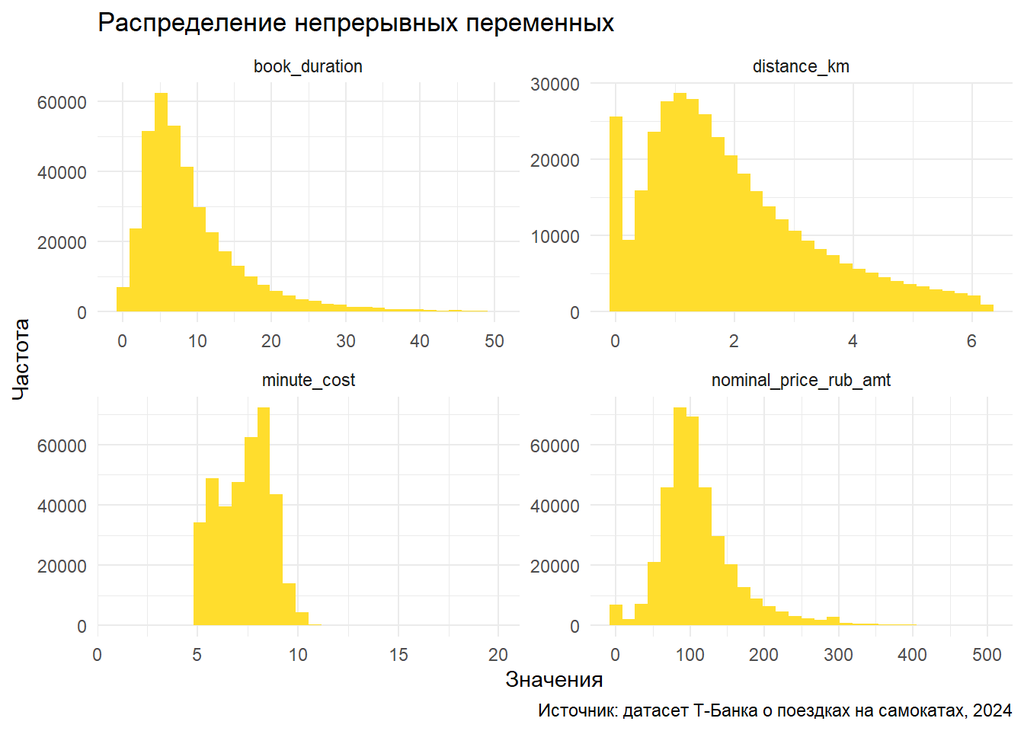

```r
kicksharing_clean %>%
  select(minute_cost, distance_km, book_duration, nominal_price_rub_amt) %>%
  filter(book_duration < 50,
         nominal_price_rub_amt < 500
         ) %>%
  pivot_longer(everything()) %>%
  ggplot(aes(value))+
  geom_histogram(fill = "#FFDD2D")+
  facet_wrap(~name, scales = "free")+
  theme_minimal()+
  labs(title = 'Распределение непрерывных переменных',
       x = "Значения",
       y = 'Частота',
       caption = 'Источник: датасет Т-Банка о поездках на самокатах, 2024')
```

## Возрастное распределение клиентов

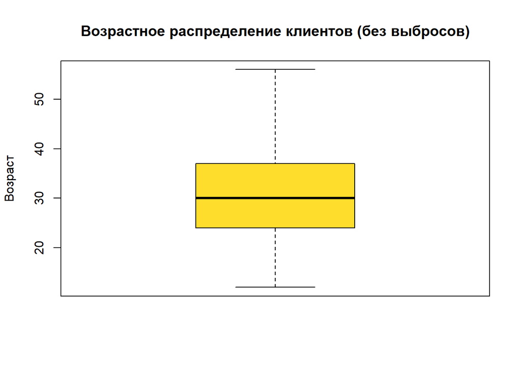

```r
iqr_age <- IQR(kicksharing_clean$age)

lower_bound_age = quantile(kicksharing_clean$age, 0.25) - 1.5 * iqr_age
upper_bound_age = quantile(kicksharing_clean$age, 0.75) + 1.5 * iqr_age

kicksharing_clean %>%
  select(age) %>%
  filter(age <= upper_bound_age & age >= lower_bound_age) %>%
  boxplot(main = 'Возрастное распределение клиентов (без выбросов)',
       ylab = 'Возраст',
       caption = 'Источник: датасет Т-Банка о поездках на самокатах, 2024',
       col = '#FFDD2D')
```

## Длительность поездки среди мужчин и женщин

Чтобы проверить свою основную гипотезу, я создаю новую переменную “длительность поездки” и очищаю ее от выбросов. Построив график, показываю среднюю длительность поездки среди мужчин и женщин. Как видно из графика, **женщины ездят на самокатах сервиса немного дольше, чем мужчины** (в среднем больше восьми минут).

```r
# определяю численные значения в новой переменной для учета выбросов

iqr_dur <- IQR(kicksharing_clean$book_duration)

lower_bound_dur = quantile(kicksharing_clean$book_duration, 0.25) - 1.5 * iqr_dur
upper_bound_dur = quantile(kicksharing_clean$book_duration, 0.75) + 1.5 * iqr_dur

summary(kicksharing_clean$book_duration)
```

```
##     Min.  1st Qu.   Median     Mean  3rd Qu.     Max.
##   0.0334   4.5938   7.3183   9.6014  11.8464 319.2502
```

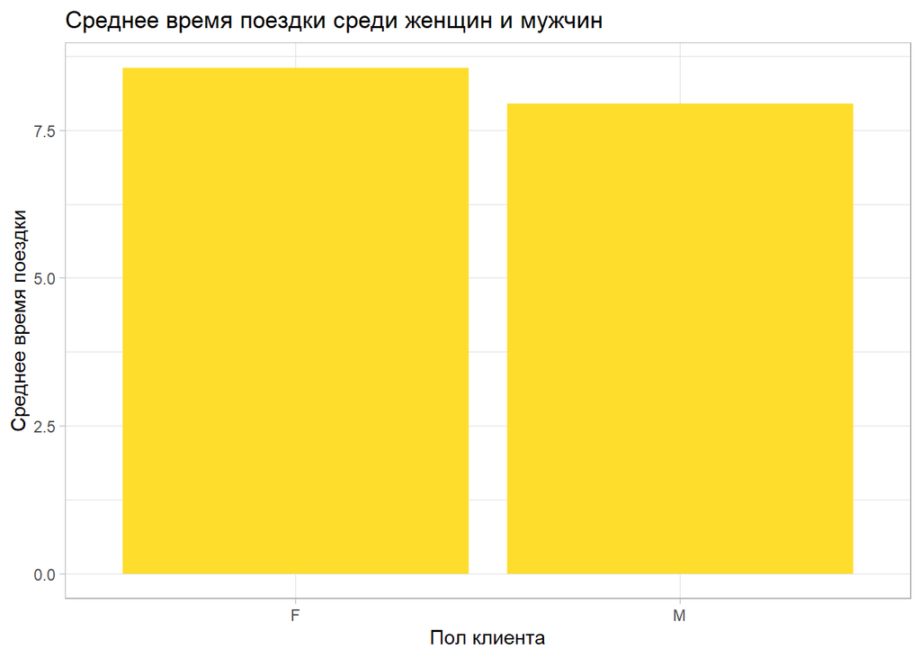

```r
# визуализирую средние значения длительности поездок для мужчин и женщин

kicksharing_clean %>%
  select(gender_cd, book_duration) %>%
  filter(book_duration <= upper_bound_dur
         & book_duration >= lower_bound_dur
         & is.na(gender_cd) == FALSE) %>%
  group_by(gender_cd) %>%
  summarise(average_duration = mean(book_duration)) %>%
  ggplot(aes(gender_cd, average_duration))+
  geom_col(fill = '#FFDD2D')+
  theme_light()+
  labs(title = "Среднее время поездки среди женщин и мужчин", y = 'Среднее время поездки', x = 'Пол клиента')
```

## Длина поездки по месяцам

```r
summary(kicksharing_clean$distance_km)
```

```
##    Min. 1st Qu.  Median    Mean 3rd Qu.    Max.
##  0.0000  0.8917  1.6095  1.9258  2.6949  6.2475
```

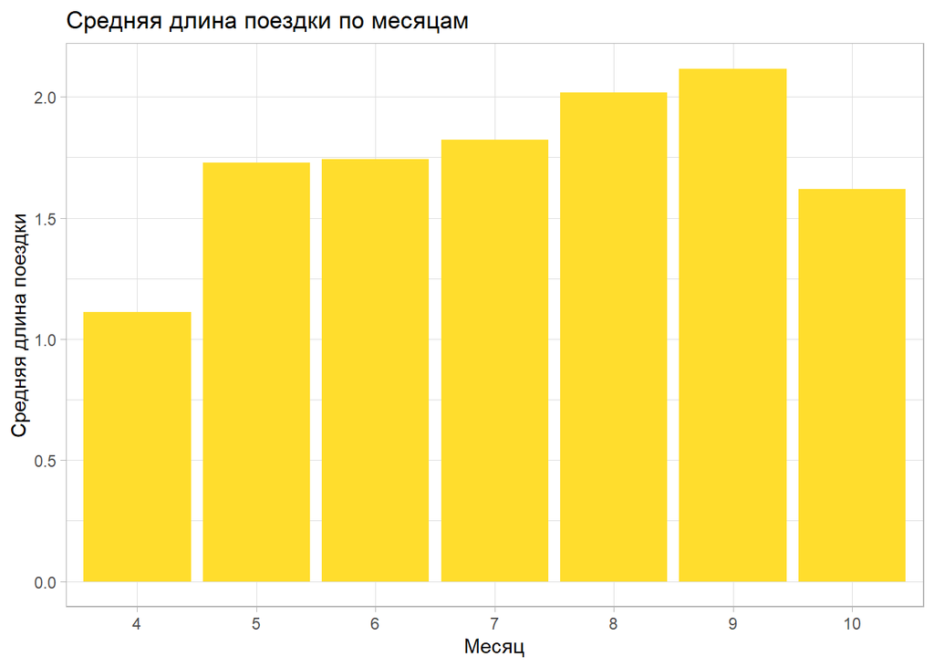

```r
kicksharing_clean %>%
  mutate(month = as.factor(month(created_dttm))) %>%
  select(month, distance_km) %>%
  filter(is.na(month) == FALSE) %>%
  group_by(month) %>%
  summarise(average_distance = mean(distance_km)) %>%
  ggplot(aes(month, average_distance))+
  geom_col(fill = '#FFDD2D')+
  theme_light()+
  labs(title = "Средняя длина поездки по месяцам",
       y = 'Средняя длина поездки',
       x = 'Месяц')
```

## Половое распределение клиентов в 10 самых активных регионах

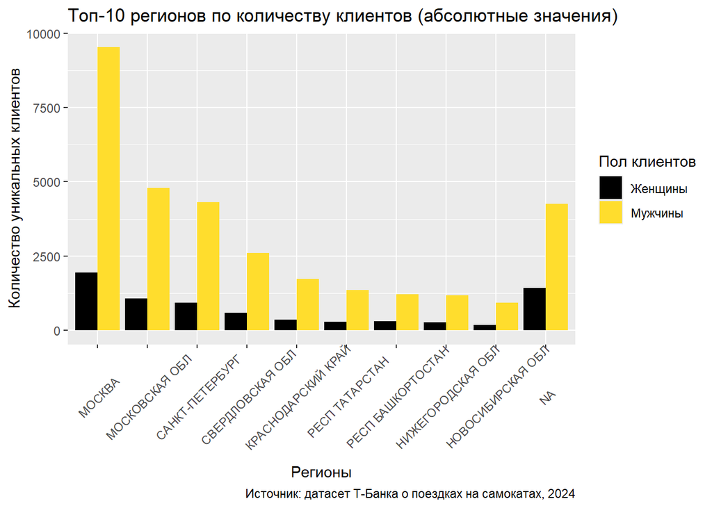

```r
# сохраняю датафрейм с нужными данными для последующей визуализации

top_regions_gender <- kicksharing_clean %>%
  select(lvn_state_nm,
         distance_km,
         book_duration,
         party_rk,
         gender_cd) %>%
  group_by(lvn_state_nm) %>%
  summarise(clients_amt = n_distinct(party_rk),
            male_clients = n_distinct(party_rk[gender_cd == "M"]),
            female_clients = n_distinct(party_rk[gender_cd == "F"])) %>%
  arrange(desc(clients_amt)) %>%
  slice_head(n = 10) %>%
  mutate(top_regions = fct_reorder(lvn_state_nm, clients_amt, .desc = TRUE)) %>%
  pivot_longer(
    cols = c(male_clients, female_clients),
    names_to = "gender",
    values_to = "count") %>%
  mutate(gender = case_when(
    gender == "male_clients" ~ "Мужчины",
    gender == "female_clients" ~ "Женщины"))

#　абсолютные значения для полового распределения

top_regions_gender %>%
ggplot(aes(top_regions,
             count, fill = gender))+
  geom_col(position = 'dodge')+
  theme(axis.text.x = element_text(angle = 45, vjust = 0.6))+
  scale_fill_manual(values = c("Мужчины" = "#FFDD2D", "Женщины" = "#000000"))+
  labs(title = "Топ-10 регионов по количеству клиентов (абсолютные значения)",
       caption = "Источник: датасет Т-Банка о поездках на самокатах, 2024",
       x = 'Регионы',
       y = 'Количество уникальных клиентов',
       fill = 'Пол клиентов')
```

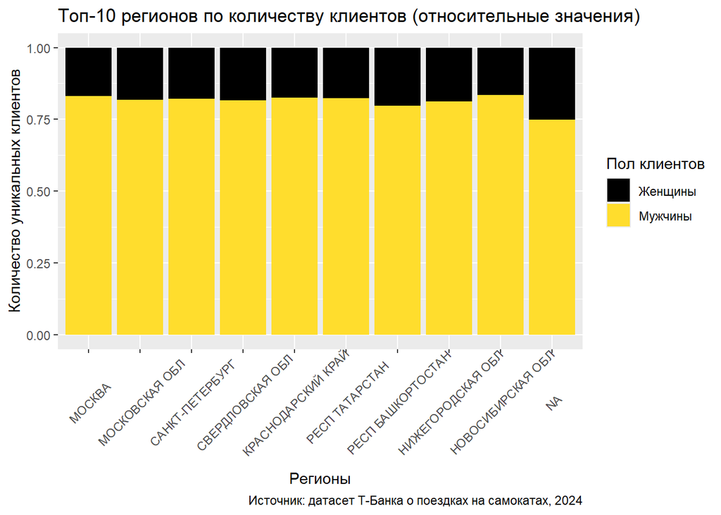

```r
# относительные значения для полового распределения

top_regions_gender %>%
  ggplot(aes(top_regions,
             count, fill = gender))+
  geom_col(position = 'fill')+
  theme(axis.text.x = element_text(angle = 45, vjust = 0.6))+
  scale_fill_manual(values = c("Мужчины" = "#FFDD2D", "Женщины" = "#000000"))+
  labs(title = "Топ-10 регионов по количеству клиентов (относительные значения)",
       caption = "Источник: датасет Т-Банка о поездках на самокатах, 2024",
       x = 'Регионы',
       y = 'Количество уникальных клиентов',
       fill = 'Пол клиентов')
```

## Самые активные часы заказов кикшеринга

Также мне было интересно посмотреть, какие часы явлются пиковыми для сервиса кикшеринга. График показывает, что эти часы - **в 5 утра** (предположительно до начала работы метрополитена в городах) и **с 14 до 17 вечера**. Визуализация этих данных представлена в виде столбчатой диаграммы и тепловой карты.

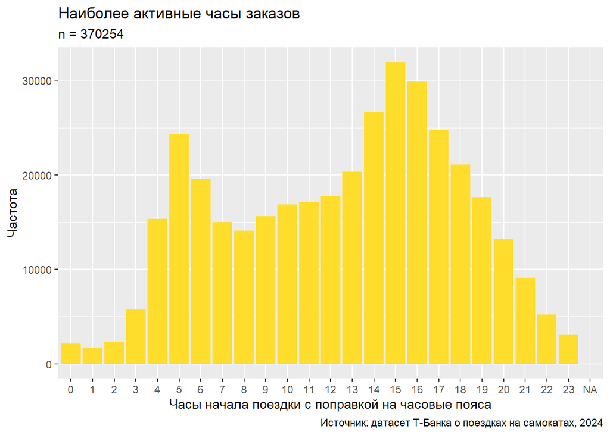

```r
kicksharing_clean <- kicksharing_clean %>%
  mutate(
    timezone_int = as.integer(gsub("0", "", as.character(book_time_zone_cd))),
    hour_int = lubridate::hour(book_start_dttm),
    adjusted_hour = as.factor((hour_int + (timezone_int - 3)) %% 24))

kicksharing_clean %>%
  select(adjusted_hour) %>%
  group_by(adjusted_hour) %>%
  summarise(freq = n()) %>%
  ggplot(aes(adjusted_hour, freq))+
  geom_col(fill = '#FFDD2D')+
  labs(
    title = 'Наиболее активные часы заказов',
    x = 'Часы начала поездки с поправкой на часовые пояса',
    y = 'Частота',
    caption = 'Источник: датасет Т-Банка о поездках на самокатах, 2024',
    subtitle = 'n = 370254'
    )
```

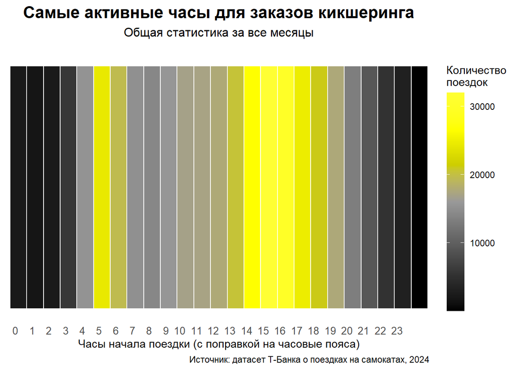

```r
kicksharing_clean %>%
  select(adjusted_hour) %>%
  group_by(adjusted_hour) %>%
  summarise(freq = n(), .groups = 'drop') %>%
  ggplot(aes(x = adjusted_hour, y = 1, fill = freq)) +
  geom_tile(color = "white", linewidth = 0.5) +
  scale_fill_gradientn(
    colors = c("black", "#333333", "#666666", "#999999",
               "#CCCC00", "#FFFF00", "#FFFF33"),
    name = "Количество\nпоездок"
  ) +
  scale_x_discrete(breaks = 0:23) +
  labs(
    title = "Самые активные часы для заказов кикшеринга",
    subtitle = "Общая статистика за все месяцы",
    x = "Часы начала поездки (с поправкой на часовые пояса)",
    y = NULL,
    caption = "Источник: датасет Т-Банка о поездках на самокатах, 2024")+
  theme_minimal()+
  theme(
    axis.text.y = element_blank(),
    axis.text.x = element_text(hjust = 1, size = 10),
    panel.grid = element_blank(),
    plot.title = element_text(face = "bold", size = 16, hjust = 0.5),
    plot.subtitle = element_text(size = 12, hjust = 0.5, margin = margin(b = 15)),
    legend.position = "right",
    legend.key.height = unit(1.5, "cm"))
```

## Т-Тест для основной гипотезы

Моя основная гипотеза состояла в том, что средняя длина поездок у женщин выше, чем у мужчин. На предыдущих этапах я уже визуализировала данные и выяснила, что это действительно так, но мне требуется проверить результаты на статистическую значимость, так как выборка женщин в целом в несколько раз меньше, чем мужчин. Для проверки я использую t-тест Уэлча для двух выборок. Результат теста показал, что p-value значительно меньше уровня значимости = 0,05. Это значит, что нулевая гипотеза о том, что поездки женщин короче, чем у мужчин, может быть отвергнута с высокой степенью уверенности. Соответственно, женщины действительно совершают более длительные поездки по сравнению с мужчинами.

```r
women <- kicksharing_clean %>%
  select(gender_cd, book_duration) %>%
  filter(gender_cd == 'F'
         & book_duration <= upper_bound_dur
         & book_duration >= lower_bound_dur)

men <- kicksharing_clean %>%
  select(gender_cd, book_duration) %>%
  filter(gender_cd == 'M'
         & book_duration <= upper_bound_dur
         & book_duration >= lower_bound_dur)

t.test(women$book_duration, men$book_duration, alternative = "greater", var.equal = FALSE)
```

```
##
##  Welch Two Sample t-test
##
## data:  women$book_duration and men$book_duration
## t = 25.366, df = 66161, p-value < 2.2e-16
## alternative hypothesis: true difference in means is greater than 0
## 95 percent confidence interval:
##  0.5733843       Inf
## sample estimates:
## mean of x mean of y
##  8.556868  7.943725
```

```r
t_test_welch <- t.test(book_duration ~ gender_cd,
                      data = kicksharing_clean,
                      alternative = "greater")
t_test_welch
```

```
##
##  Welch Two Sample t-test
##
## data:  book_duration by gender_cd
## t = 30.151, df = 69994, p-value < 2.2e-16
## alternative hypothesis: true difference in means between group F and group M is greater than 0
## 95 percent confidence interval:
##  1.2495    Inf
## sample estimates:
## mean in group F mean in group M
##       10.730942        9.409344
```